# How well does Language at 3 predict Language at 5?

Yeeka Yau

Friday, July 08, 2016

# The Dataset

The standard language scores between ages 2,3,4 and 5 were analysed, from 150 graduates of the past 4 years (2012-2015). For the purposes of this brief study, no other variables about a client’s record were taken into account.

## Language at 2 vs Language at 5

The following correlation plot has been produced for graduates with at least a language score at 2 and a language score at 5. There were 50 graduates in this cohort:

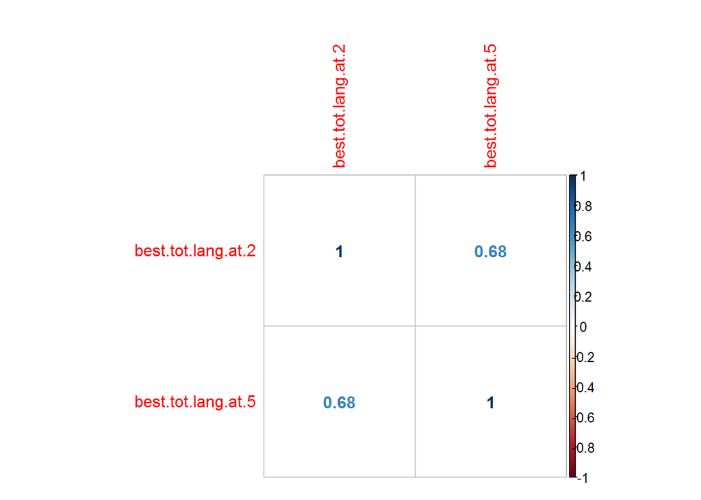

The following correlation plot is for graduates with at least a language scores at 2, 3 and 5. There were 42 graduates in this cohort:

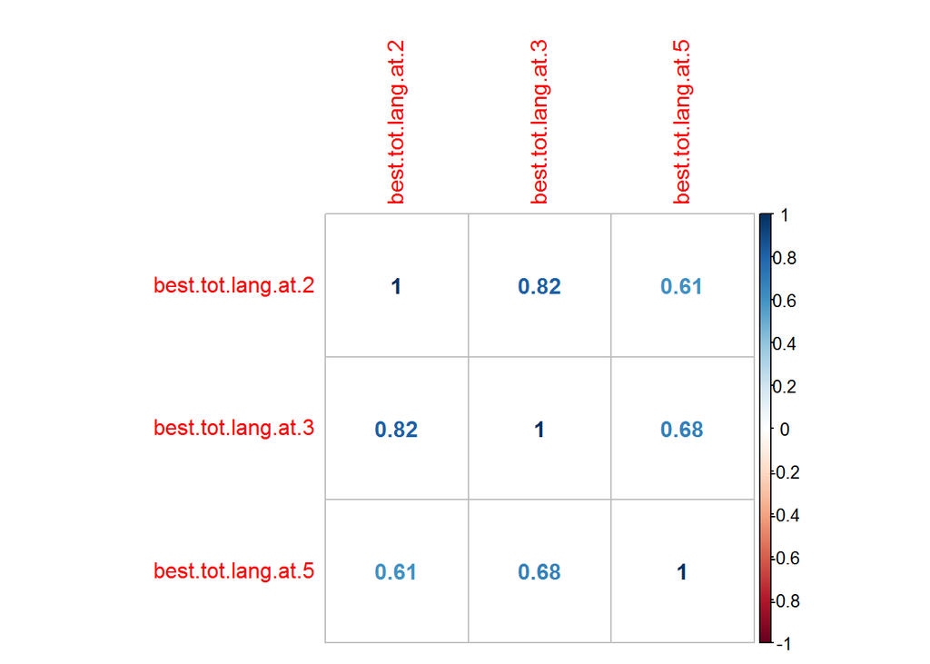

The following correlation plot has been produced for graduates with language scores at 2, 3, 4 and 5. There were 41 graduates in this cohort:

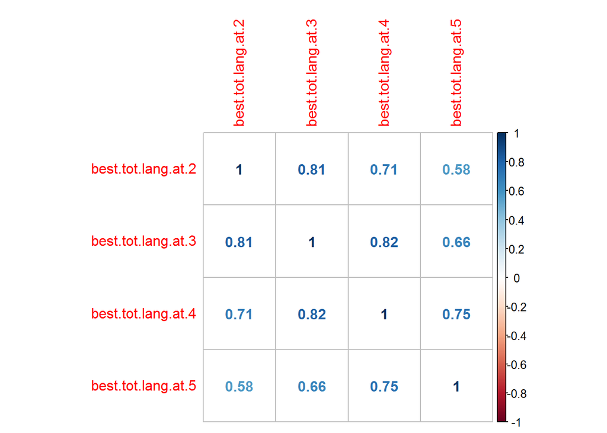

Interestingly, the correlation slightly decreases with more language data points. So the additional 8 children without a language score at 3, had relatively different standard scores at age 2 versus age 4 and 5. **It would be interesting to explore the reasons why this might be the case.**

Overall, taking into account all 3 correlation scores, **the correlation between language at 2 and language at 5 is approximately 0.62, so the strength of the linear relationship is fair**.

Here is a scatter plot of the data points:

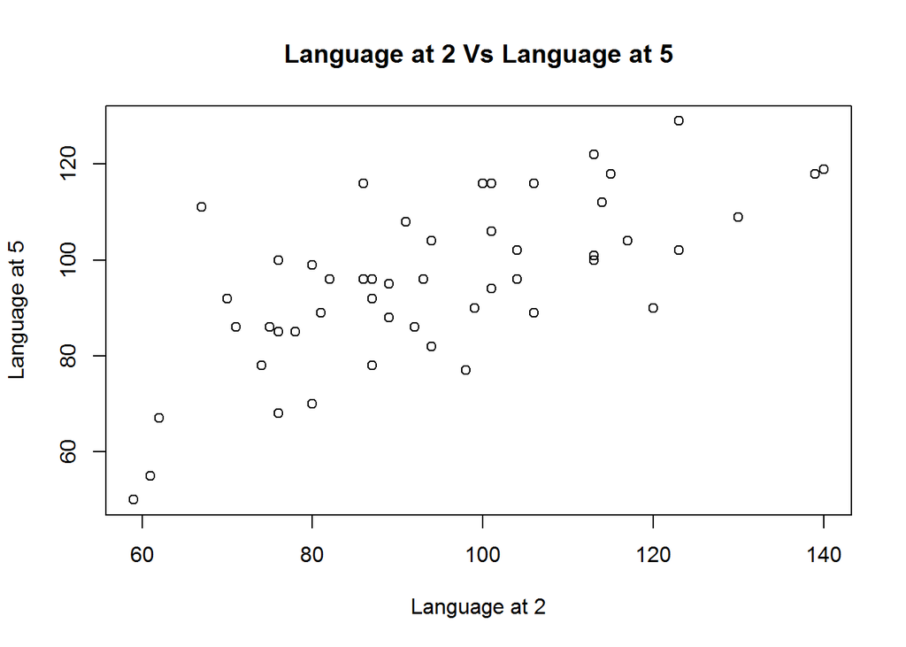

# Language at 3 predict Language at 5?

Of the 150 graduates, there were 61 clients with at least a language score at 3 and a language score at 5, and 58 clients with language scores at 3,4 and 5. The correlation plots are below:

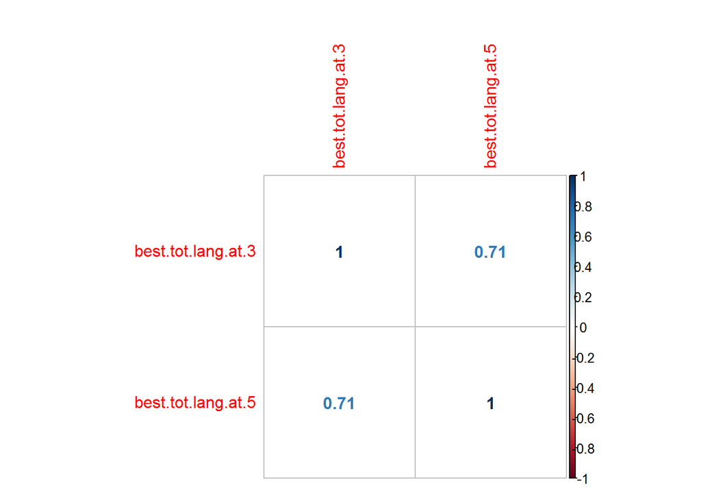

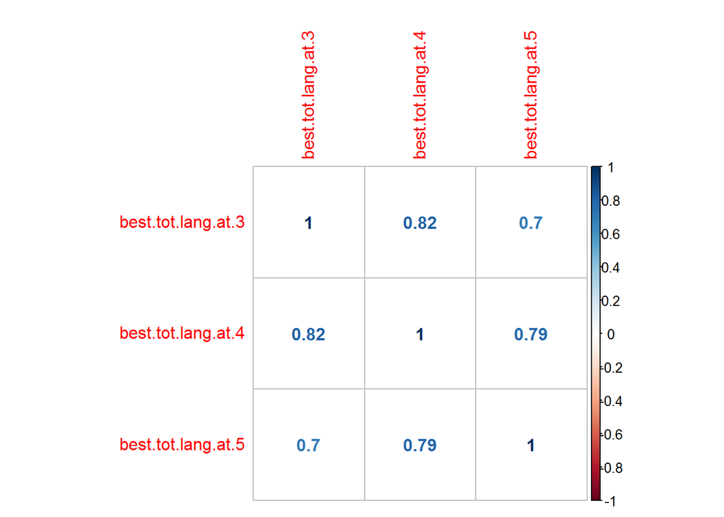

In the same manner as language prediction beginning at 2, there is a slight negative trend in correlation with more data. However, in this case, **the correlation score is reasonably high at 0.7.**

# General Linear Model

Since we want to say whether language score at 3 predicts language score at 5, a general linear regression was constructed in R using the 61 clients with at least a language score at 3 and a language score at 5. We get the following linear model:

```
##
## Call:
## lm(formula = best.tot.lang.at.5 ~ best.tot.lang.at.3, data = grad.outcomes)
##
## Coefficients:
##        (Intercept)  best.tot.lang.at.3
##            38.3255              0.6062
```

$y=0.6062x+38.3255$

Where $y =$ Language score at 5, $x =$ language score at 3. This is interpreted as: **On average, a 1 point increase in language score at 3 will result in a 0.6 point increase in language score at 5.**

Having a look at the scatter plot, we see there is a reasonable linear relationship between language at 3 and language at 5. There are 61 clients with language scores at ages 3 and 5.

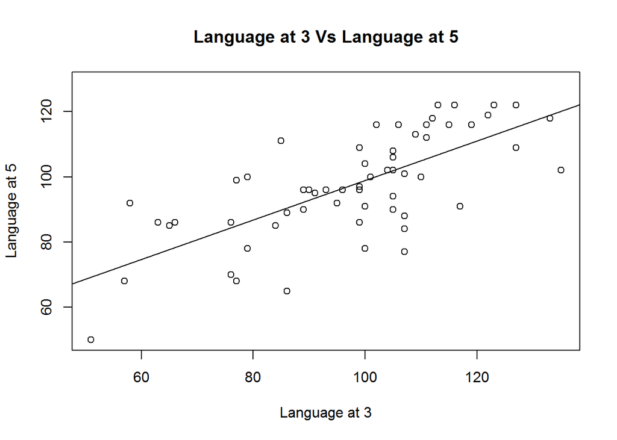

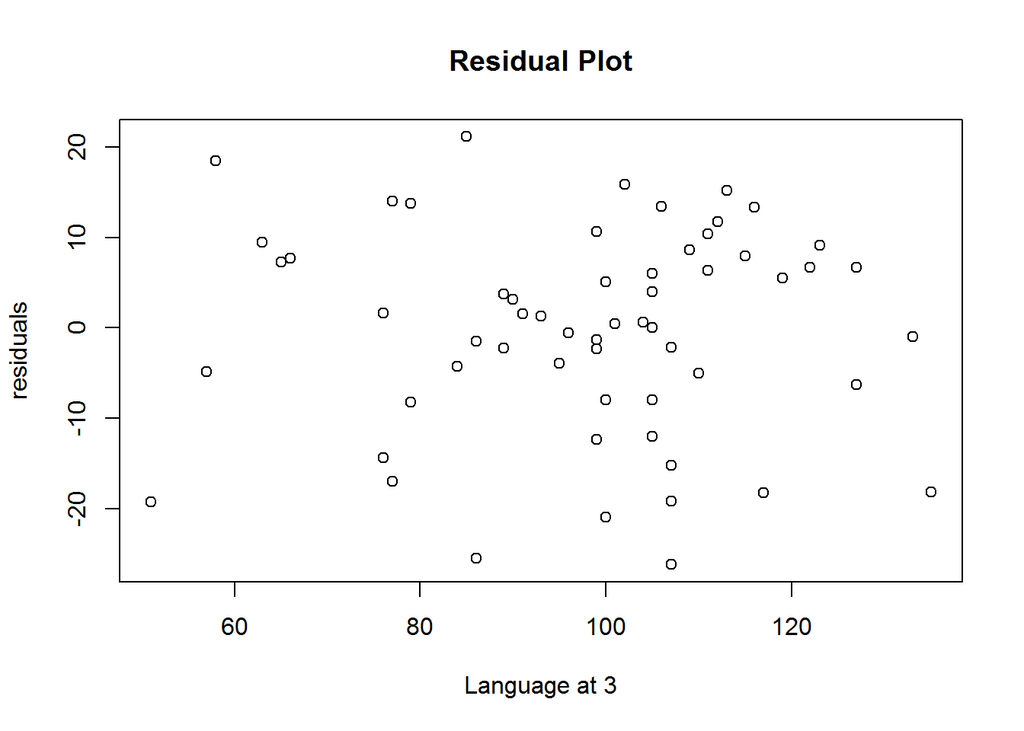

The residual plots show that the errors in the model are random and reasonably symmetrically distributed around 0, and so it is reasonable to use a linear model.

# Goodness of Fit

```
##
## Call:
## lm(formula = best.tot.lang.at.5 ~ best.tot.lang.at.3, data = grad.outcomes)
##
## Residuals:
##     Min      1Q  Median      3Q     Max
## -26.186  -6.310   1.300   7.964  21.149
##
## Coefficients:
##                    Estimate Std. Error t value Pr(>|t|)
## (Intercept)        38.32552    7.86700   4.872 8.67e-06 ***
## best.tot.lang.at.3  0.60618    0.07881   7.692 1.82e-10 ***
## ---
## Signif. codes:  0 '***' 0.001 '**' 0.01 '*' 0.05 '.' 0.1 ' ' 1
##
## Residual standard error: 11.47 on 59 degrees of freedom
##   (89 observations deleted due to missingness)
## Multiple R-squared:  0.5007, Adjusted R-squared:  0.4922
## F-statistic: 59.16 on 1 and 59 DF,  p-value: 1.821e-10
```

The key number here is the adjusted R-Squared of 0.49, which is interpreted as **Approximately 50% of the variation in language scores at 5 can be explained by the language score at 3.**

The closer the $R^2$ is to 1, the better the fit of the model to the data, so this model is very average. (Which would be expected, as we take no other factors into account in the prediction).

In general, the model should theoretically predict a client’s language score at 5 based on their language score at 3, to within +/-11 of what their true score should be.

# Conclusion

It is fair to say that there is a **good correlation between a client’s language score at 3 and language score at 5.** There is less correlation between Language score at 2 and language at 5.

The linear model presented above also suggests that **language at 3 is a moderate predictor of language at 5 when no other factors are taken into account**, but that there is **strong evidence of a positive linear relationship between these two variables.**

The regression slope coefficient gives us a general idea of the effect on language score at 5 by increasing one’s language score at 3.